# Kalman filter and smoother: predictions and missing values

Source: [`vignettes/articles/kalman-filter.qmd`](https://github.com/cdriveraus/ctsem/blob/master/vignettes/articles/kalman-filter.qmd)

ctsem estimates the latent processes with the Kalman filter and smoother. This article shows the difference between the two on a short series with a few observations held out, and how to get estimates of the missing values, with their uncertainty.

```r
library(ctsem)
library(ggplot2)
```

## Data

One subject, observed 40 times. The process follows a first order autoregression with an equilibrium of 1, starting at 6, and each observation has measurement error with a standard deviation of 0.2:

```r
set.seed(3)
n <- 40
eta <- 6
for (i in 2:n) eta[i] <- 0.9 * eta[i - 1] + 0.1 + rnorm(1, 0, 0.5)
dat <- data.frame(id = 1, time = 1:n, y = eta + rnorm(n, 0, 0.2))
```

Six observations are kept aside, and removed from the data used for fitting:

```r
missing <- c(5, 17:19, 26, 35)
heldout <- dat[missing, ]
dat$y[missing] <- NA
head(dat)
```

```
#>   id time        y
#> 1  1    1 6.158752
#> 2  1    2 5.176335
#> 3  1    3 4.408774
#> 4  1    4 4.592951
#> 5  1    5       NA
#> 6  1    6 3.284191
```

## Model

The model is ctsem’s default continuous time model for one process measured by one variable. With so little data, the measurement error is fixed at its known standard deviation of 0.2, which separates it from the random changes in the process. With one subject, nothing varies over subjects.

```r
model <- ctModel(type = 'ct',
  manifestNames = 'y', latentNames = 'eta',
  LAMBDA = 1, MANIFESTVAR = 0.2)
model$pars$indvarying <- FALSE
```

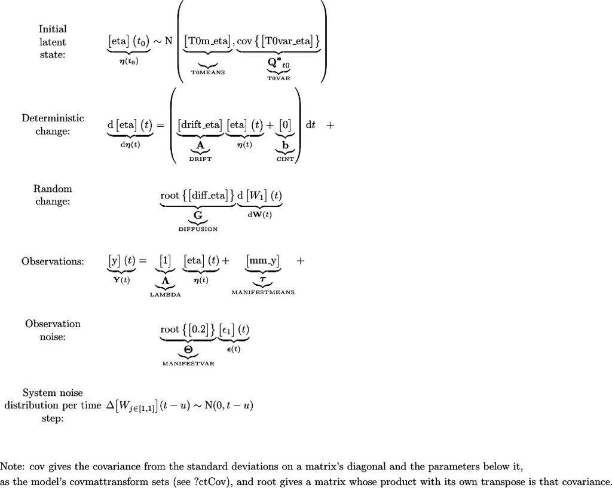

```r
fit <- ctFit(dat, model, cores = 2)
summary(fit)$popmeans
```

```
#>             mean    sd   2.5%    50%  97.5%   mode
#> T0m_eta    5.093 0.507  4.078  5.101  6.083  5.113
#> drift_eta -0.178 0.055 -0.308 -0.171 -0.092 -0.169
#> diff_eta   0.478 0.078  0.346  0.473  0.653  0.474
#> mm_y       1.035 0.474  0.109  1.036  1.983  1.021
```

## Filter and smoother

The filter works through the data in time order. At each time it first predicts the process from the observations so far (the prior, `yprior` for the observed variable and `etaprior` for the latent process), then updates that prediction with the observation at that time, if there is one. The smoother then runs back from the end of the data, so its estimates (`ysmooth`, `etasmooth`) use all the observations, before and after.

`ctPredict()` computes both, here every 0.1 time units. The held out observations are added to the plot as crosses:

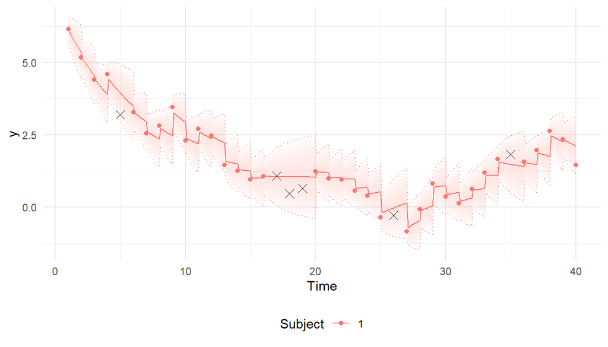

```r
ctPredict(fit, timestep = 0.1, plot = TRUE, kalmanvec = c('y', 'yprior')) +
  geom_point(data = heldout, aes(x = time, y = y), inherit.aes = FALSE,
    shape = 4, size = 3)
```

Between observations the filter’s prediction moves towards the equilibrium, at the rate the drift sets, and its uncertainty grows. When an observation arrives the prediction jumps most of the way to it, how far depending on the measurement error. Over a gap in the observations, the prediction carries on towards the equilibrium with growing uncertainty until the next observation.

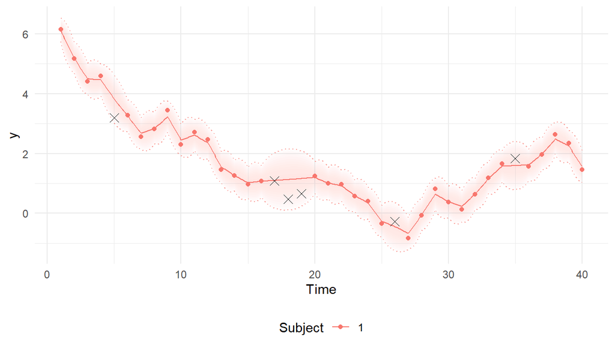

```r
ctPredict(fit, timestep = 0.1, plot = TRUE, kalmanvec = c('y', 'ysmooth')) +
  geom_point(data = heldout, aes(x = time, y = y), inherit.aes = FALSE,
    shape = 4, size = 3)
```

The smoother uses the observations after each time as well, so it bridges the gaps from both sides and is more certain. At an observed time its estimate is not the observation itself, because the observation includes measurement error.

## Estimates of the missing values

With `timestep = 'asdata'`, `ctPredict()` gives values at the times in the data only, as a long data frame with one row per time, variable and kind of estimate. The `sd` column holds each estimate’s standard deviation:

```r
k <- ctPredict(fit, timestep = 'asdata')
imputed <- k[k$Element %in% 'ysmooth' & k$Time %in% heldout$time,
  c('Time', 'value', 'sd')]
imputed$heldout <- heldout$y
imputed
```

```
#>     Time      value        sd    heldout
#> 245    5  3.8278577 0.4097326  3.1928724
#> 257   17  1.0978966 0.4725834  1.0764471
#> 258   18  1.1281695 0.5210875  0.4668347
#> 259   19  1.1615219 0.4725834  0.6548468
#> 266   26 -0.4492234 0.4097327 -0.2840927
#> 275   35  1.5938595 0.4097327  1.8267435
```

Each held out value lies within two standard deviations of its estimate. The standard deviations are larger in the middle of the gap from 17 to 19, furthest from any observation. They take the parameters at their estimates, so they leave out the uncertainty about the parameters.

To get estimates at times that are not in the data, add rows for them with the observed variables set to `NA`, either before fitting or afterwards with `ctPredict(fit, newdata = ...)`, which uses the fitted parameters without fitting again.